# Laboratorio 3 CA0411

Author

Joshua Cervantes Artavia

Published

3/26/25

# Descripción del laboratorio

En este laboratorio se va buscar diseñar nuestro propio ACP normado de tal forma que lo podamos estimar a “mano”.

Recordemos que en este caso que la forma de obtener el ACP era diagonalizando o obtiniendo los autovarlores y autovectores de la matriz de correlaciones. Más adelante se va ver una versión más general de nuestro ACP.

```python
#Se carga el modulo
from cod.acp import AFC
import pandas as pd
import numpy as np
import matplotlib.pyplot as plt
import seaborn as sns
```

En este caso se programó el método AFC para el caso de las nubes de perfiles fila y se procede a obtener las componentes a partir de las fórmulas de transición.

# Ejemplo de colegios

Se va ver el caso de los colegios y la relación con la escogencia del colegio.

Se procede a cargar los datos

```python
df_colegios = pd.read_excel("./data/lab_3.xlsx", index_col=[0])
df_colegios
```

| TIPO_COLEGIO | UCR | ITCR | UNA | UNED |
| --- | --- | --- | --- | --- |
| diurno-oficial | 21088 | 2643 | 1991 | 1972 |
| nocturno-oficial | 2047 | 274 | 388 | 678 |
| diurno-privado | 2044 | 213 | 121 | 150 |
| nocturno-privado | 133 | 16 | 31 | 47 |
| bachillerato por madurez | 0 | 0 | 85 | 179 |
| colegio-extranjero | 250 | 90 | 53 | 51 |

Procedemos a generar el objeto a partir de clase que programamos

```python
afc_colegios = AFC(df_colegios)

df_colegios.sum(axis =1)
```

```
TIPO_COLEGIO
diurno-oficial              27694
nocturno-oficial             3387
diurno-privado               2528
nocturno-privado              227
bachillerato por madurez      264
colegio-extranjero            444
dtype: int64
```

Vemos las matrices $M = D^{-1}_{y}$ y $D = D_{x}$

```python
afc_colegios.M
```

```
array([[ 1.35138096,  0.        ,  0.        ,  0.        ],
       [ 0.        , 10.67490729,  0.        ,  0.        ],
       [ 0.        ,  0.        , 12.94267516,  0.        ],
       [ 0.        ,  0.        ,  0.        , 11.22651934]])
```

```python
afc_colegios.D
```

```
array([[0.80170218, 0.        , 0.        , 0.        , 0.        ,
        0.        ],
       [0.        , 0.09804887, 0.        , 0.        , 0.        ,
        0.        ],
       [0.        , 0.        , 0.07318203, 0.        , 0.        ,
        0.        ],
       [0.        , 0.        , 0.        , 0.00657133, 0.        ,
        0.        ],
       [0.        , 0.        , 0.        , 0.        , 0.00764243,
        0.        ],
       [0.        , 0.        , 0.        , 0.        , 0.        ,
        0.01285317]])
```

Se procede a realizar el AFC

```python
afc_colegios.afc()
```

En este caso se obtiene que los autovalores no incluyen al 1, esto es porque fue eliminado en el código para evitar confusiones, pero si se dejara se observaría que es 1 y además el autovector es el centro de gravedad.

```python
afc_colegios.eig_vals
```

```
array([0.06715016, 0.00255011, 0.00023309])
```

Se puede observar que se tienen 3 autovectores.

```python
afc_colegios.eig_vecs
```

```
array([[-0.76362178, -0.72064432,  0.00789799],
       [-0.07169862,  0.65316541,  0.38422768],
       [ 0.24037371,  0.19462763, -0.81872865],
       [ 0.59494669, -0.12714871,  0.42660298]])
```

Se estima la varianza explicada por las primeras componentes

```python
afc_colegios.explained_variance(3)
```

```
array([0.96020212, 0.03646481, 0.00333307])
```

Se estiman los primeros tres componentes principales

```python
afc_colegios.principal_components(3)
```

```
array([[-1.59565998e-01,  3.31574597e-03, -2.12206185e-02],
       [ 1.00781834e+00, -2.16923178e-02,  8.30678073e-02],
       [-3.53639593e-01, -1.64065733e-01,  1.31196396e-01],
       [ 1.14920867e+00, -3.06821937e-02, -1.60141519e-01],
       [ 5.53035992e+00, -1.56803491e-01, -1.64496548e-01],
       [ 4.02377364e-01,  1.00172244e+00,  1.22630338e-01]])
```

Se proceden a ejecutar las fórmulas de transición

```python
afc_colegios.transicion()
```

Al ejecutar las constribución del primer individuo en la primera componente se puede observar que este es menor 1 tal y como se espera.

```python
afc_colegios.contribucion_pf(i = 1,component = 1)
```

```
np.float64(0.30398120106007226)
```

Al realizar los mismo en las componentes filas se observa lo mismo.

```python
afc_colegios.contribucion_col(j = 1,component = 1)
```

```
np.float64(0.7880148576844369)
```

Al graficar podemos observar el comportamiento que se tiene en el libro que justamente nos muestra el alejamiento de los extranjeros y los colegios con bachillerato por madurez. En este caso se encuentra que los ejes están invertidos, pero se concluye lo mismo. Esto puede suceder dependiendo del lenguaje que estén usando.

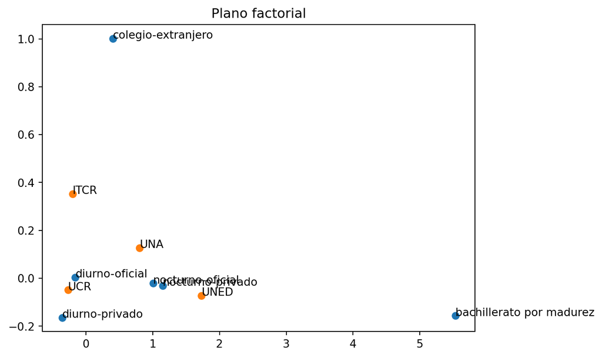

```python
afc_colegios.plot_coords(axis_x = 1, axis_y = 2)
```

# Ejemplo de gasolina

Se va ver el ejemplo de la gasolina regular comprada por marca y tipo de vehículo

```python
df_gasolina = pd.read_excel("./data/lab_3.xlsx", sheet_name = "GASOLINA", index_col=[0])
df_gasolina
```

| marca | auto | jeep | cl | cp | taxi | mtp | mf | o tipo |
| --- | --- | --- | --- | --- | --- | --- | --- | --- |
| chev | 14.52 | 13.32 | 17.32 | 17.32 | 11.36 | 18.98 | 0.00 | 0.00 |
| dait | 11.00 | 14.34 | 26.07 | 26.70 | 24.41 | 0.00 | 0.00 | 17.04 |
| fiat | 20.00 | 31.74 | 24.08 | 24.08 | 73.86 | 0.00 | 19.57 | 0.00 |
| hyun | 16.22 | 0.00 | 15.30 | 15.30 | 17.41 | 0.00 | 0.00 | 0.00 |
| isuzu | 18.45 | 23.32 | 17.61 | 17.61 | 0.00 | 1.13 | 0.00 | 0.00 |
| mazda | 11.63 | 0.00 | 18.23 | 18.23 | 17.04 | 0.00 | 0.00 | 11.59 |
| mitsu | 19.01 | 29.35 | 15.48 | 15.48 | 20.76 | 0.00 | 0.00 | 11.36 |
| nissan | 14.81 | 29.11 | 15.92 | 15.92 | 24.47 | 8.52 | 15.81 | 0.00 |
| subaru | 17.26 | 0.00 | 16.86 | 16.86 | 11.36 | 17.04 | 14.55 | 11.36 |
| suzuki | 24.07 | 18.81 | 18.54 | 18.54 | 11.36 | 0.00 | 11.70 | 0.00 |
| toyota | 16.13 | 14.31 | 18.95 | 18.95 | 20.20 | 16.53 | 15.19 | 13.69 |
| o marca | 18.85 | 18.52 | 22.36 | 22.36 | 23.74 | 69.31 | 27.25 | 16.56 |

Procedemos a generar el objeto

```python
afc_gasolina = AFC(df_gasolina)

df_gasolina.sum(axis =1)
```

```
marca
chev        92.82
dait       119.56
fiat       193.33
hyun        64.23
isuzu       78.12
mazda       76.72
mitsu      111.44
nissan     124.56
subaru     105.29
suzuki     103.02
toyota     133.95
o marca    218.95
dtype: float64
```

Se procede a ejecutar el AFC

```python
afc_gasolina.afc()
```

Una vez más se observa que todos los autovalores son menores que 1.

```python
afc_gasolina.eig_vals
```

```
array([1.91274568e-01, 8.20758159e-02, 6.61645093e-02, 3.39949055e-02,
       2.38898073e-02, 4.12121317e-03, 2.10843526e-06])
```

```python
afc_gasolina.eig_vecs
```

```
array([[-1.70725228e-01, -4.01171042e-02, -2.98926802e-01,
         4.51454529e-01, -2.86248102e-01, -7.19802768e-01,
        -1.65397277e-02],
       [-2.70312550e-01,  5.94225273e-01, -4.01877655e-01,
        -6.73847744e-01,  1.18706915e-01,  3.00498712e-02,
         1.67819042e-03],
       [-1.77482059e-01, -3.16470926e-01, -1.54560422e-01,
         2.77774918e-01,  3.23131954e-02,  4.35539977e-01,
         7.15702230e-01],
       [-1.79786677e-01, -3.24348834e-01, -1.53571809e-01,
         2.70058238e-01,  3.60656125e-02,  4.67726129e-01,
        -6.98200564e-01],
       [-3.35421740e-01,  2.09251419e-01,  7.97711873e-01,
         2.67265625e-02,  5.49995677e-01, -1.91035197e-01,
        -2.58019150e-03],
       [ 8.12794248e-01,  6.90351952e-02, -9.63614057e-02,
         5.38363423e-02,  3.77268025e-01, -4.58318648e-02,
        -1.49212236e-03],
       [ 2.28728780e-01,  3.36085399e-01,  2.19859356e-01,
         2.72113617e-02, -6.52717285e-01,  1.41389049e-01,
         6.84167890e-04],
       [ 9.22052252e-02, -5.27660421e-01,  8.77268648e-02,
        -4.33214208e-01, -1.75384037e-01, -1.18035198e-01,
         7.48017342e-04]])
```

En este caso se obtiene la inercia explicada por las primeras 5 componentes.

```python
afc_gasolina.explained_variance(5)
```

```
array([0.47637272, 0.20441128, 0.16478389, 0.08466492, 0.05949799])
```

Se conservan solo tres ya que vamos a graficar en el primer plano factorial.

```python
afc_gasolina.principal_components(3)
```

```
array([[ 0.67738508,  0.13065896, -0.78538404],
       [-0.99497496, -1.45942601,  0.14764128],
       [-1.12587138,  1.09927854,  1.05242239],
       [-1.34167936, -0.71230535,  0.20994014],
       [-1.25628927,  0.34749343, -1.83194969],
       [-0.88506788, -2.12743787,  0.4375595 ],
       [-1.22424881, -0.17234869, -0.42631468],
       [-0.26303944,  1.33987458, -0.00894446],
       [ 1.2711559 , -0.80026961,  0.23550106],
       [-0.89808452,  0.66154971, -0.55039657],
       [ 0.64788916, -0.28525731,  0.19350941],
       [ 2.58990279,  0.17487747,  0.01118253]])
```

Se ejecutan las fórmulas de transición.

```python
afc_gasolina.transicion()
```

Se obtiene la contribución que efectivamente es menor que 1

```python
afc_gasolina.contribucion_pf(i = 1,component = 1)
```

```
np.float64(0.15658820248440777)
```

Los mismo para los perfiles columna

```python
afc_gasolina.contribucion_col(j = 1,component = 1)
```

```
np.float64(0.20523342323143934)
```

Se procede a hacer el primer plano factorial, en este caso se puede observar que existe un comportamiento interesanete donde la mayoría de las marcas se ubican al lado izquierdo mientras las de las derecha se ubican a las derecha, por lo que puede intuirse que tiene un consumo diferente de gasolina y además etán más relacionadas con mtp al menos el resto de marcas. o tipo (otro tipo) se ubica realmente alejado de los demás.

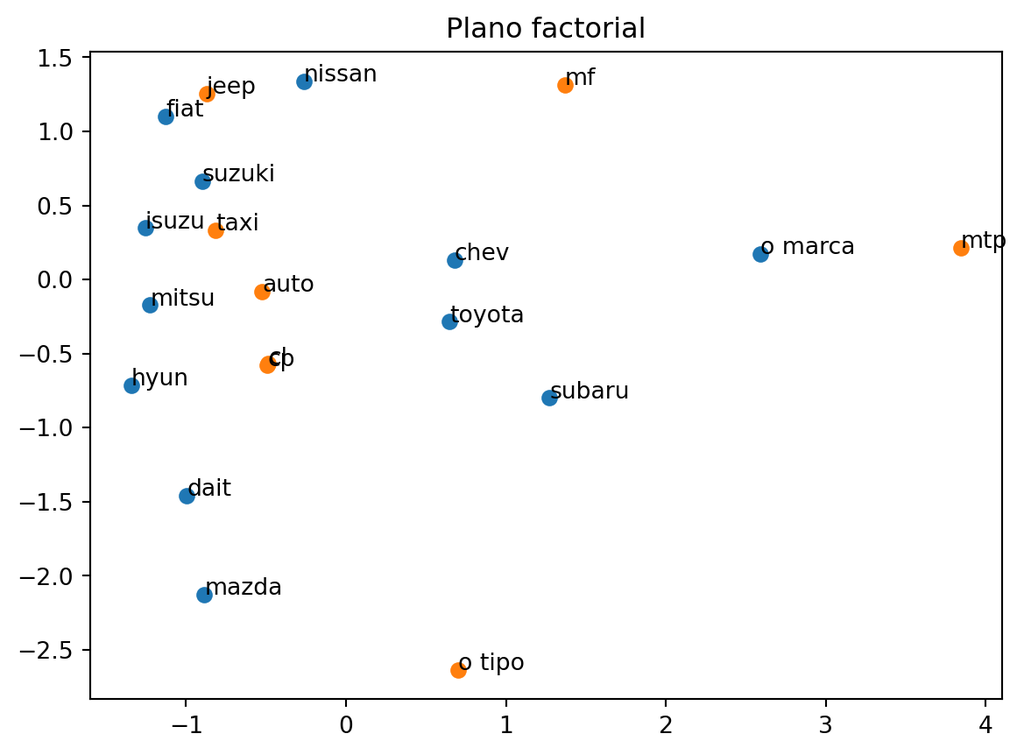

```python
afc_gasolina.plot_coords(axis_x = 1, axis_y = 2)
```